# Fruitful Spending: Which Produce Gives the Best Bite for Your Buck?

Misgana Bekele, Marlene Berrios, and Elizabeth Kenreck

Have you ever wondered which fruits and vegetables are the most and least expensive?

This project explores the retail prices of fruits and vegetables in different forms. Using the 2022 fruit and vegetable price datasets, we compared retail prices, cup equivalent prices, and average prices by market form.

The goal was to identify any possible differences between fruit and vegetable prices according to the form they were sold in.

Both data sets are from the Economic Research Service on the the US Department of Agriculture website; http://www.ers.usda.gov/data-products/fruit-and-vegetable-prices.

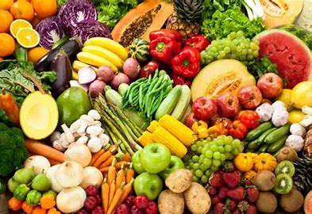

some fruit

```
## Rows: 62
## Columns: 8
## $ Fruit              <chr> "Apples", "Apples, applesauce", "Apples, ready-to-d…
## $ Form               <chr> "Fresh", "Canned", "Juice", "Juice", "Fresh", "Cann…
## $ RetailPrice        <dbl> 1.8541, 1.1705, 0.8699, 0.6086, 3.6162, 1.8645, 2.2…
## $ RetailPriceUnit    <chr> "per pound", "per pound", "per pint", "per pint", "…
## $ Yield              <dbl> 0.90, 1.00, 1.00, 1.00, 0.93, 1.00, 0.65, 1.00, 0.6…
## $ CupEquivalentSize  <dbl> 0.2425, 0.5401, 8.0000, 8.0000, 0.3638, 0.5401, 0.4…
## $ CupEquivalentUnit  <chr> "pounds", "pounds", "fluid ounces", "fluid ounces",…
## $ CupEquivalentPrice <dbl> 0.4996, 0.6323, 0.4349, 0.3043, 1.4145, 1.0071, 1.5…
```

```
## Rows: 93
## Columns: 8
## $ Vegetable          <chr> "Acorn squash", "Artichoke", "Artichoke", "Asparagu…
## $ Form               <chr> "Fresh", "Fresh", "Canned", "Fresh", "Canned", "Fro…
## $ RetailPrice        <dbl> 1.2136, 2.4703, 3.4498, 2.9531, 3.4328, 6.8212, 2.6…
## $ RetailPriceUnit    <chr> "per pound", "per pound", "per pound", "per pound",…
## $ Yield              <dbl> 0.4586, 0.3750, 0.6500, 0.4938, 0.6500, 1.0335, 0.7…
## $ CupEquivalentSize  <dbl> 0.4519, 0.3858, 0.3858, 0.3968, 0.3968, 0.3968, 0.3…
## $ CupEquivalentUnit  <chr> "pounds", "pounds", "pounds", "pounds", "pounds", "…
## $ CupEquivalentPrice <dbl> 1.1961, 2.5415, 2.0476, 2.3731, 2.0958, 2.6191, 1.1…
```

| Fruit | Form | CupEquivalentPrice |
| --- | --- | --- |
| Cherries, packed in syrup or water | Canned | 3.5558 |
| Raspberries | Fresh | 2.5753 |
| Blackberries | Fresh | 2.2471 |
| Raspberries | Frozen | 2.0368 |
| Cherries | Fresh | 1.7321 |
| Pomegranate, ready-to-drink | Juice | 1.6394 |
| Blackberries | Frozen | 1.5965 |
| Apricots, packed in syrup or water | Canned | 1.5169 |
| Pomegranate | Fresh | 1.5055 |
| Fruit cocktail, packed in syrup or water | Canned | 1.4242 |
| Pears, packed in syrup or water | Canned | 1.4191 |
| Apricots | Fresh | 1.4145 |
| Berries, mixed | Frozen | 1.4112 |
| Blueberries | Fresh | 1.3990 |
| Grapefruit | Fresh | 1.3647 |
| Peaches, packed in syrup or water | Canned | 1.3636 |
| Kiwi | Fresh | 1.3231 |
| Fruit cocktail, packed in juice | Canned | 1.2931 |
| Mangoes | Dried | 1.2906 |
| Blueberries | Frozen | 1.2636 |
| Figs | Dried | 1.2613 |
| Peaches, packed in juice | Canned | 1.2155 |
| Pineapple, packed in syrup or water | Canned | 1.2055 |
| Peaches | Frozen | 1.1924 |
| Plum (prunes) | Dried | 1.1861 |
| Pears, packed in juice | Canned | 1.1559 |
| Papaya | Dried | 1.1552 |
| Strawberries | Frozen | 1.1052 |
| Apricots | Dried | 1.0978 |
| Pineapple | Dried | 1.0823 |
| Strawberries | Fresh | 1.0094 |
| Apricots, packed in juice | Canned | 1.0071 |
| Plum | Fresh | 0.9775 |
| Clementines | Fresh | 0.9507 |
| Dates | Dried | 0.9507 |
| Honeydew | Fresh | 0.9442 |
| Pineapple, packed in juice | Canned | 0.8917 |
| Oranges | Fresh | 0.8771 |
| Plum (prune), ready-to-drink | Juice | 0.8494 |
| Nectarines | Fresh | 0.8333 |
| Peaches | Fresh | 0.7755 |
| Mangoes | Fresh | 0.7531 |
| Pears | Fresh | 0.7466 |
| Grapes | Fresh | 0.7014 |
| Papaya | Fresh | 0.6658 |
| Grapes (raisins) | Dried | 0.6603 |
| Apples, applesauce | Canned | 0.6323 |
| Cranberries | Dried | 0.6260 |
| Pineapple, ready-to-drink | Juice | 0.6122 |
| Grapefruit, ready-to-drink | Juice | 0.5968 |
| Cantaloupe | Fresh | 0.5528 |
| Oranges, ready-to-drink | Juice | 0.5286 |
| Grapes, ready-to-drink | Juice | 0.5255 |
| Apples | Fresh | 0.4996 |
| Pineapple | Fresh | 0.4401 |
| Apples, ready-to-drink | Juice | 0.4349 |
| Grapes, frozen concentrate | Juice | 0.3762 |
| Oranges, frozen concentrate | Juice | 0.3669 |
| Pineapple, frozen concentrate | Juice | 0.3628 |
| Bananas | Fresh | 0.3085 |
| Apples, frozen concentrate | Juice | 0.3043 |
| Watermelon | Fresh | 0.2429 |

According to the data shown:

- Canned cherries, packed in syrup or water were the most expensive fruit at $3.55 per cup.
- Fresh watermelons were the least expensive at $0.24 per cup.

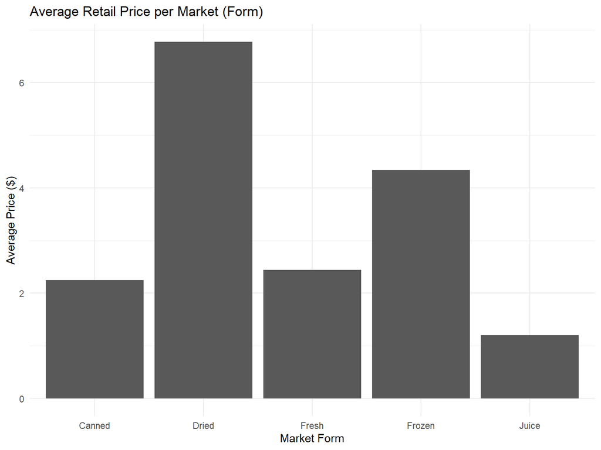

- Dried market form showed an overall higher average price.
- Fruit juice showed the overall lowest average price.
- Canned and fresh fruit showed a similar average price.

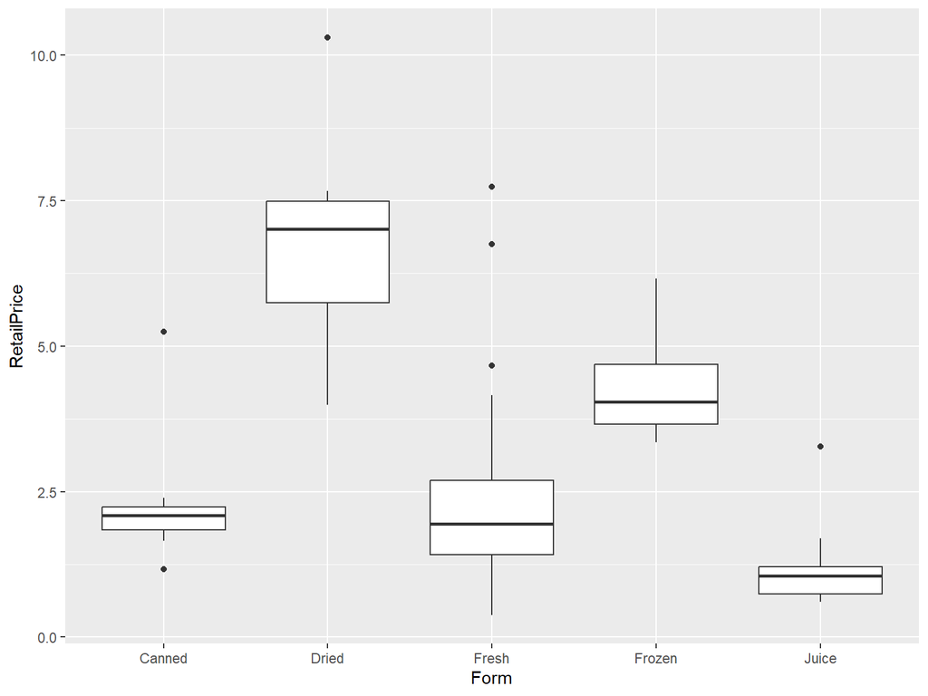

- Dried fruits showed a higher average price per cup range.
- Fresh showed a greater amount of outliers.
- Juice showed the lowest average price per cup range.

| Vegetable | Form | CupEquivalentPrice |
| --- | --- | --- |
| Asparagus | Frozen | 2.6191 |
| Artichoke | Fresh | 2.5415 |
| Asparagus | Fresh | 2.3731 |
| Okra | Fresh | 2.3639 |
| Asparagus | Canned | 2.0958 |
| Artichoke | Canned | 2.0476 |
| Spinach, boiled | Fresh | 1.7700 |
| Tomatoes, grape & cherry | Fresh | 1.5950 |
| Olives | Canned | 1.5922 |
| Corn | Fresh | 1.5009 |
| Broccoli heads | Fresh | 1.3502 |
| Turnip greens | Fresh | 1.2467 |
| Acorn squash | Fresh | 1.1961 |
| Avocados | Fresh | 1.1538 |
| Turnip greens | Frozen | 1.1440 |
| Spinach | Frozen | 1.1010 |
| Cauliflower florets | Fresh | 1.0800 |
| Mustard greens | Frozen | 1.0756 |
| Pumpkin | Canned | 1.0069 |
| Broccoli florets | Fresh | 0.9965 |
| Collard greens | Frozen | 0.9699 |
| Brussels sprouts | Fresh | 0.9394 |
| Okra | Frozen | 0.9387 |
| Kale | Fresh | 0.9373 |
| Kale | Frozen | 0.9295 |
| Brussels sprouts | Frozen | 0.9237 |
| Broccoli | Frozen | 0.9090 |
| Spinach | Canned | 0.9039 |
| Tomatoes, large round | Fresh | 0.9006 |
| Green beans | Fresh | 0.8528 |

[output cut: 63 more lines]

According to the data shown:

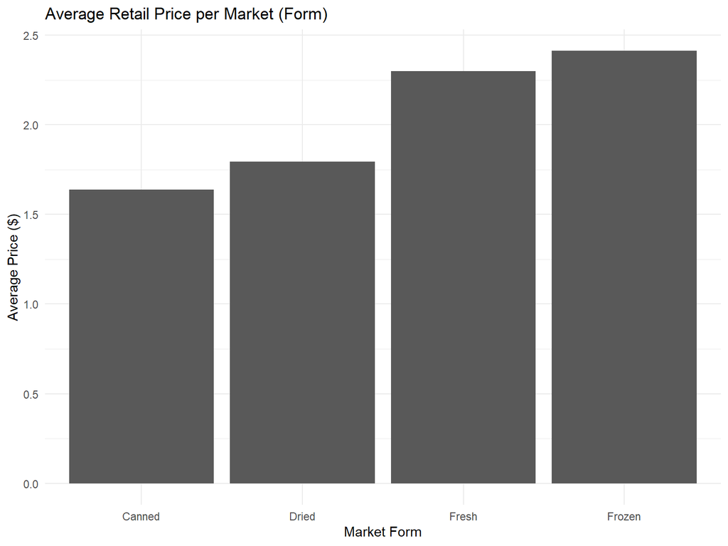

- Frozen vegetables showed a higher average price range.
- Canned vegetables showed the least average price range.
- The average price range was very narrow with a maximum difference of $1 between vegetable prices, based on their market form.

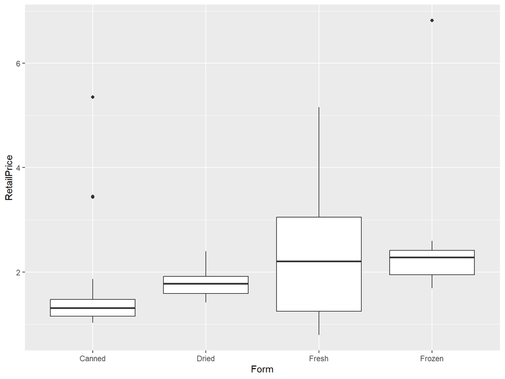

- Fresh vegetables showed a greater range in price per cup.
- Canned showed a smaller range but had outliers that had a higher average retail price per cup.

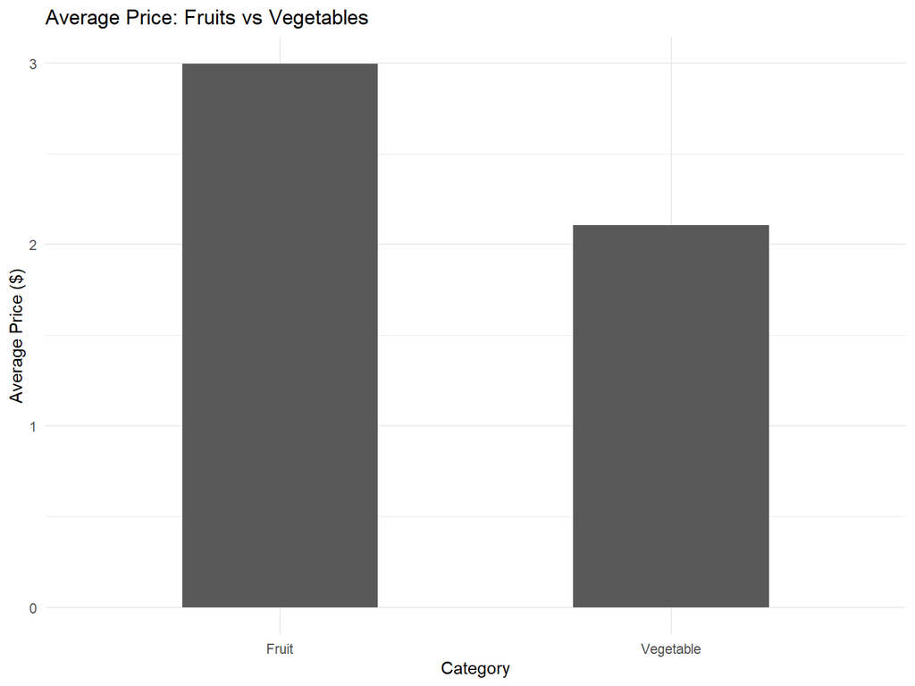

- Overall, fruit showed a higher average price per category compared to vegetables per cup.
- This suggested a higher spending on price per cup when purchasing fruit compared to vegetables.

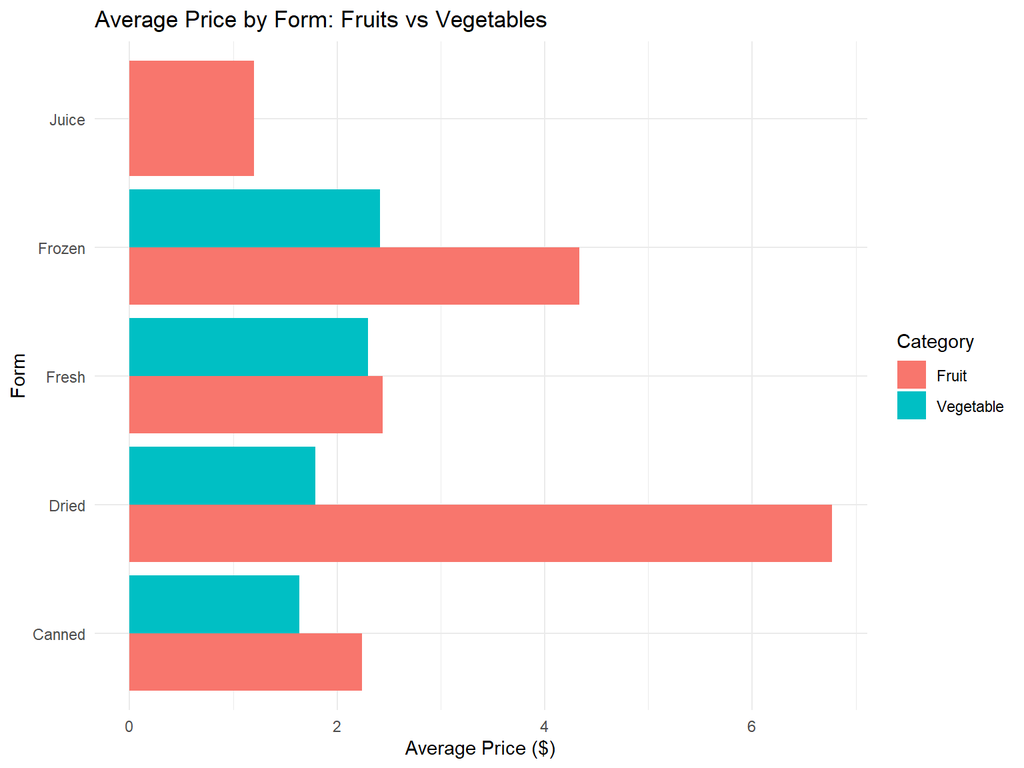

- **Juice:** Vegetables prices were not affected since data was not provided for vegetables in this specific form.
- **Frozen:** About a $2 difference in average price was shown between the categories.
- **Fresh:** The average price showed very little difference.
- **Dried:** Showed the largest difference in average price of almost $5.
- **Canned:** Showed a relatively small difference.

What are the best choices for a tight budget?

Each price is calculated based on a **5-cup** quantity, which provides a clearer view of the actual cost to purchase a **reasonable** amount.

**Meal Idea Under $10: Lentil Stew**

$1.43 - Lentils

$1.33 - Potatoes

$1.51 - Carrots

$2.16 - Onions

$1.69 - Cabbage

$1.19 - Black Beans

**Total:** $9.31

**Fruit Snack ideas under $5:**

$1.21 Watermelon

$1.54 Bananas

$2.20 Pineapple

**Total:** $4.95

9 different produce items x 5 cups each = 45 cups

$9.31 + $4.95 = $14.26

**A meal and a snack would total $14.26, less than $15 for 45 cups of produce!**

If someone wanted to buy 5 cups of produce on a $3 budget, what combinations would work?

| Fruit | Form | Priceper5cups |
| --- | --- | --- |
| Grapefruit, ready-to-drink | Juice | 2.9840 |
| Cantaloupe | Fresh | 2.7640 |
| Oranges, ready-to-drink | Juice | 2.6430 |
| Grapes, ready-to-drink | Juice | 2.6275 |
| Apples | Fresh | 2.4980 |
| Pineapple | Fresh | 2.2005 |
| Apples, ready-to-drink | Juice | 2.1745 |
| Grapes, frozen concentrate | Juice | 1.8810 |
| Oranges, frozen concentrate | Juice | 1.8345 |
| Pineapple, frozen concentrate | Juice | 1.8140 |
| Bananas | Fresh | 1.5425 |
| Apples, frozen concentrate | Juice | 1.5215 |
| Watermelon | Fresh | 1.2145 |

| Vegetable | Form | Priceper5cups |
| --- | --- | --- |
| Carrots | Canned | 2.9460 |
| Tomatoes | Canned | 2.8935 |
| Sweet potatoes | Fresh | 2.8910 |
| Carrots | Frozen | 2.8180 |
| Radish | Fresh | 2.7750 |
| Potatoes | Canned | 2.6985 |
| Cabbage, red | Fresh | 2.6750 |
| Green beans | Canned | 2.5850 |
| Lettuce, romaine, heads | Fresh | 2.5705 |
| Tomatoes, roma & plum | Fresh | 2.5645 |
| Green peppers | Fresh | 2.3855 |
| Cucumbers without peel | Fresh | 2.2600 |
| Onions | Fresh | 2.1675 |
| Celery, trimmed bunches | Fresh | 2.1085 |
| Carrots, cooked whole | Fresh | 1.9125 |
| Carrots, baby | Fresh | 1.8610 |
| Lima beans | Dried | 1.8180 |
| Cucumbers with peel | Fresh | 1.7010 |
| Cabbage, green | Fresh | 1.6920 |
| Lettuce, iceberg | Fresh | 1.5970 |
| Carrots, raw whole | Fresh | 1.5110 |
| Kidney beans | Dried | 1.4980 |
| Blackeye peas | Dried | 1.4630 |
| Lentils | Dried | 1.4365 |
| Great northern beans | Dried | 1.3440 |
| Potatoes | Fresh | 1.3315 |
| Navy beans | Dried | 1.2555 |
| Black beans | Dried | 1.1915 |
| Pinto beans | Dried | 1.1075 |

There are only **13 fruit** options and **29 vegetable** options to fit this scenario.

Some Examples of what produce you would have been able to buy in this scenario are:

**Possible vegetables under $3 for 5 cups**

- Canned carrots for **$2.94** – Most expensive option
- Dried pinto beans for **$1.10** – Cheapest option

**Possible fruits under $3 for 5 cups**

- Grapefruit juice for **$2.98** – Most expensive option
- Fresh watermelon for **$1.21** – Cheapest option

One of the most interesting patterns from the 2022 data is how **dried fruits** had the **highest average prices**, despite being sold in **smaller quantities**. This shows a key point: Price per unit does not always reflect volume, some of the most expensive items give you the least actual food.

This is an important reminder that when comparing prices, context matters, and “more expensive” does **NOT** always mean “better value.”